# Deconvolution with Scaden

Regina H. Reynolds

UCL

> Aim: to use the cell deconvolution algorithm, Scaden, to approximate the cell type composition of a given bulk tissue sample.

# 1 File paths/files for workflow

```r
source(here::here("R", "file_paths.R"))

path_to_results <- file.path(path_to_wd, "results")
path_to_raw_data <- file.path(path_to_wd, "raw_data")

sample_info <-
  read_excel(path =
               file.path(
                 path_to_raw_data,
                 "sample_details/20201229_MasterFile_SampleInfo.xlsx"
               ),
             sheet = "SampleInfo", skip = 1) %>%
  dplyr::filter(Sample_Type == "Tissue section" & sent_to_bulk_seq == "yes") %>%
  dplyr::select(CaseNo, Disease_Group, Sex, AoO, AoD, DD, PMI, aSN, TAU, 'thal AB', 'aCG aSN score', Genetics, RINe_bulkRNA_Tapestation) %>%
  dplyr::mutate(Disease_Group = fct_relevel(Disease_Group,
                                            c("Control", "PD", "PDD","DLB"))) %>%
  dplyr::rename(sample_id = CaseNo)
```

# 2 Background

## 2.1 Scaden

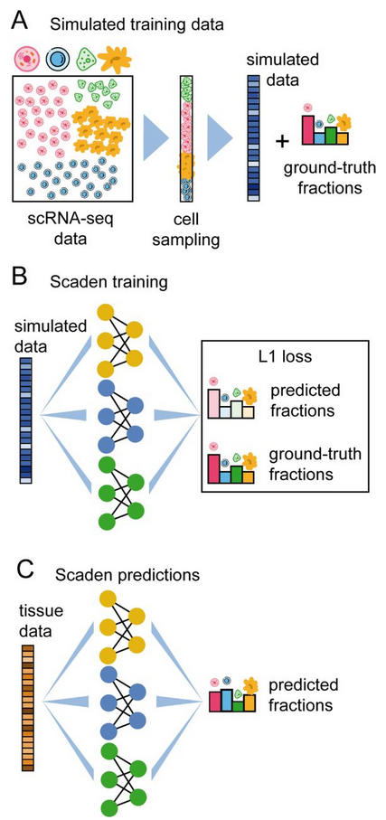

**Overview of training data and cell type deconvolution with Scaden.** A: Artificial bulk samples are generated by subsampling random cells from a scRNA-seq datasets and merging their expression profiles. B: Model training and parameter optimization on simulated tissue RNA-seq data by comparing cell fraction predictions to ground-truth cell composition. C: Cell deconvolution of real tissue RNA-seq data using Scaden.

# 3 Implementing Scaden

1. Training data generation and pre-processing.
   1. Requires transforming single-nuclear count data from logarithmic space to non-logarithmic space. As a part of pre-processing, training data is log2-transformed and scaled to the range [0,1], thus it is important that count data is not already in logarithmic space.
2. Training of 3 deep neural network models.
3. Prediction of cell-type proportions in bulk tissue.

## 3.1 Training data generation

Steps include:

1. Pre-processing bulk data
   1. Should be a file of shape genes x samples i.e. each row corresponds to a gene and each sample to a column. Leave the column name for the genes empty (just put '').
   2. File required prior to use `scaden process` command, as this command looks for intersection of genes between training and prediction data.
2. Pre-processing snRNA-seq data
   1. Normalise count data (first author used [sc.pp.normalize_per_cell](https://scanpy.readthedocs.io/en/stable/api/scanpy.pp.normalize_per_cell.html), which normalises each cell by total count over all genes, resulting in every cell having same total count after normalisation).
   2. Save this count data as '*_norm_counts_all.txt', with cells as rows and genes as columns.
   3. Save cell type labels as '*_celltypes.txt', with cells as rows and two columns, named "Celltype" and "ID". Order of cells in this file should be the same as in the count data.
3. Bulk simulation using bulk_simulation.py provided by Scaden.
4. Combine artificial samples into h5ad file using create_h5ad_file.py

### 3.1.1 Pre-processing snRNA-seq data

- As data was log-normalised using using NormalizeData(..., normalization.method = "LogNormalize", scale.factor = 10000, ...) (https://rdrr.io/cran/Seurat/man/NormalizeData.html) had to transform data to non-logarithmic scale. Transformed to library-scaled counts (i.e. gene count/total count).
- Also had to format files to suit Scaden requirements.
- Used script: snRNAseq_transform_logcounts_to_raw.R.

```r
source(here::here("misc_scripts", "snRNAseq_transform_logcounts_to_raw.R"))
```

### 3.1.2 Pre-processing bulk data

- Normalised raw counts by library size
- Swapped ensembl IDs to gene names
- Important that variance across genes within a sample is greater than 0.1. When calling command `scaden process` a smaller function within this command (`get_signature_genes`) is used to find the common genes between the training and prediction data. To do this it first computes the variance of each genes across samples and only includes those with a variance > 0.1 (line 80, in `scaden/scaden/model/functions.py`: `keep = data.var(axis=1) > var_cutoff`). Thus, important to scale bulk RNA-seq data to ensure variance isn't too small. Scaled by 1E6.
- Note: loaded dds has already had ENCODE blacklist regions removed. Only common genes between snRNAseq and bulk RNAseq are used.

```r
source(here::here("R", "biomart_df.R"))
dds <-
  readRDS(
    file =
      file.path(
        path_to_results,
        "Salmon_quant/bulk_tissue/PD_tissue_polyA_DESeqDataSet_design_SexRINAoD.Rds"
      )
  )

# Library size matrix
lib_matrix <- colSums(counts(dds)) %>%
    as.matrix() %>%
    t()

lib_matrix <- lib_matrix[rep(1, times = nrow(counts(dds))),]

# Divide raw counts by library size and scale with 1E6
norm_counts <- (counts(dds)/lib_matrix) * 1000000

# Processing for final scaden format
# Convert ensembl IDs to gene symbols
norm_counts <- norm_counts %>%
  as.data.frame() %>%
  rownames_to_column(var = "gene") %>%
  biomart_df(columnToFilter = "gene", mart = 38, attributes = c("ensembl_gene_id", "hgnc_symbol"), filter = "ensembl_gene_id") %>%
  dplyr::select(gene, hgnc_symbol, everything())

# Filter out rows where ensembl ID has no corresponding gene symbol
# Remove duplicate hgnc_symbols (i.e. multiple ensembl ids mapping to same hgnc_symbol)
norm_counts <- norm_counts %>%
  dplyr::filter(hgnc_symbol != "") %>%
  dplyr::filter(!(duplicated(hgnc_symbol) | duplicated(hgnc_symbol, fromLast = TRUE))) %>%
  dplyr::select(-gene)

# Save for scaden
write_delim(format(norm_counts, scientific = FALSE),
            path =
              file.path(
                path_to_raw_data,
                "deconvolution/scaden/bulkRNAseq_norm_counts.txt"
              ),
            delim = "\t")
```

## 3.2 Bulk simulation and creation of h5ad file

- To enable Scaden to leverage the heterogeneity of multi-subject data, training data was generated separately for every subject in the dataset
- As performed in paper with multi-subject data, 1000 simulated samples generated per subject i.e. total of 24,000 simulated samples.
  - Per subject, used 100 randomly selected cells to generate 1 simulated bulk sample. Performed according to usage.
  - Are 100 cells really sufficient?

```bash
# initiate docker
docker run --name scaden_rreynolds -it kevinmenden/scaden

# to exit
exit

# to re-connect to scaden_rreynolds container and get a bash shell in the container
docker exec -it scaden_rreynolds bash

#---Generating training data----------------------------------------
# required installation of anndata module (not within container)
pip install anndata

# copy files into container from server
docker cp /home/rreynolds/projects/Aim2_PDsequencing_wd/raw_data/deconvolution/scaden/2019Oct scaden_rreynolds:/home/data/PD_seq/

# move files within docker to directory samples/
cd /home/data/PD_seq/scaden/
mkdir samples
mv *.txt samples/

# make folder for simulated samples
mkdir /home/data/PD_seq/scaden/cells.100_samples.1000/samples_simulated

# bulk simulation
python /opt/conda/pkgs/scaden-0.9.0-py_0/site-packages/scaden/preprocessing/bulk_simulation.py --cells 100 --samples 1000 --data /home/data/PD_seq/scaden/samples/ --out /home/data/PD_seq/scaden/cells.100_samples.1000/samples_simulated/

# Create h5ad file
python /opt/conda/pkgs/scaden-0.9.0-py_0/site-packages/scaden/preprocessing/create_h5ad_file.py --data /home/data/PD_seq/scaden/cells.100_samples.1000/samples_simulated/ --out /home/data/PD_seq/scaden/cells.100_samples.1000/pdseq_bulksim.h5ad

#---pre-processing of data----------------------------------------
scaden process /home/data/PD_seq/scaden/cells.100_samples.1000/pdseq_bulksim.h5ad /home/data/PD_seq/scaden/samples/bulkRNAseq_norm_counts.txt --processed_path /home/data/PD_seq/scaden/cells.100_samples.1000/processed_pdseq_bulksim.h5ad
```

## 3.3 Training neural networks

- According to usage guide, 20000 steps is default and sufficient for datasets with 30000 samples
- According to article, 5000 steps recommended to avoid domain overfitting on simulated tissue data, which would decrease model performance on real tissue RNA-seq data
- Settled on 5000 (for now), given publication. May be something that needs re-visiting.

```bash
mkdir scaden_model_5000steps

scaden train  /home/data/PD_seq/scaden/cells.100_samples.1000/processed_pdseq_bulksim.h5ad --model_dir /home/data/PD_seq/scaden/cells.100_samples.1000/scaden_model_5000steps --steps  5000
```

## 3.4 Prediction

```bash
scaden predict /home/data/PD_seq/scaden/samples/bulkRNAseq_norm_counts.txt --model_dir /home/data/PD_seq/scaden/cells.100_samples.1000/scaden_model_5000steps --outname /home/data/PD_seq/scaden/cells.100_samples.1000/scaden_predictions_cells.100:samples.1000.txt

# exit docker
exit

# copy output to server
docker cp scaden_rreynolds:/home/data/PD_seq/scaden/cells.100_samples.1000/scaden_predictions_cells.100:samples.1000.txt /home/rreynolds/projects/Aim2_PDsequencing_wd/results/deconvolution/scaden/2019Oct/scaden_predictions_cells.100:samples.1000.txt
```

# 4 Initial results

- How can we validate the results?
  1. One approach is to determine the ranking of each cell type predicted by scaden or determined by snRNA-seq cell-type assignment and to compare these rankings. Not completely ideal, given that there is preferential selection of some cell types in snRNA-seq, so this does not represent the absolute truth.
  2. Average cell-type proportions predicted by scaden across disease groups and look at general trends -- does it compare with biology?
     - We have some idea of what to expect in terms of cell-type proportions from literature (https://www.ncbi.nlm.nih.gov/pubmed/27187682).
     - That is, we expect a ~1.5 glia-to-neuron ratio in grey matter of the cerebral cortex.
     - In cortical grey matter:
       - Oligodendrocyte proportions in the glial population may vary between 36.6-75.6% (37-76%). Mean value across 3 studies: 52.2
       - Astrocyte proportions in the glial population may vary between 17.3-46.5% (17-47%). Mean value across 3 studies: 36.75
       - Microglial proportions in the glial population may vary between 5.2-16.8% (5-17%). Mean value across 3 studies: 10.8833333
       - Range of estimates based on Table 3 in [von Bartheld et al. 2016](https://www.ncbi.nlm.nih.gov/pubmed/27187682). Looked at those rows with entries for all 3 cell types, only GM and cortex (i.e. Pope 1958, Pope 1959, Pelvig 2008)

## 4.1 Correlation of cell-type proportions within samples

```r
#----Loading results----

# Source functions
source(here::here("R", "calculate_snRNA_proportions.R"))
source(here::here("R", "scaden_rankings_and_calculate_ratios.R"))

# Calculate cell type proportions from cell type assignments
sn_proportions <-
  calculate_snRNA_proportions(
    path_to_snRNAseq_celltype_files =
      file.path(
        path_to_raw_data,
        "deconvolution/scaden/2019Oct"
      )
    )

# Create dataframe with cell type classes
cell_type_class <-
  data.frame(Celltype = sn_proportions %>%
               dplyr::select(-sample_id) %>%
               colnames() %>%
               sort(),
             Celltype_class = factor(c("Astrocyte", "Vascular", "Neuron", "Neuron",
                                       "Immune", "Oligo", "Oligo", "Vascular",
                                       "Unclassified"),
                                     levels=c("Astrocyte", "Immune", "Oligo", "Vascular",
                                              "Neuron", "Unclassified")))

# Read in scaden predictions, determine within-sample rankings of cell-types by proportions, and calculate glia-to-neuron and non-neuron-to-neuron ratios
results <-
  scaden_rankings_and_calculate_ratios(prediction_dir =
                                         file.path(
                                           path_to_results,
                                           "deconvolution/scaden/2019Oct"
                                           ),
                                       unclassified_cell_type = "Unclassified",
                                       sample_info = sample_info %>%
                                         dplyr::select(sample_id, Disease_Group),
                                       snRNAseq_proportions = sn_proportions,
                                       cell_type_class = cell_type_class,
                                       glia = vars(Astro, Microglia, Oligo, OPC),
                                       nonneuron = vars(Astro, Endo, Microglia, Oligo, OPC, Per),
                                       neuron = vars(Excitatory, Inhibitory),
                                       astrocyte = vars(Astro),
                                       oligos = vars(Oligo, OPC),
                                       microglia = vars(Microglia))

# # Export cell-type proportions
# write_delim(results$ranks %>%
#               dplyr::select(-rank_within_sample),
#             "/home/rreynolds/projects/Aim2_PDsequencing_wd/results/deconvolution/scaden/2019Oct/scaden_summary_results.txt", delim = "\t")
```

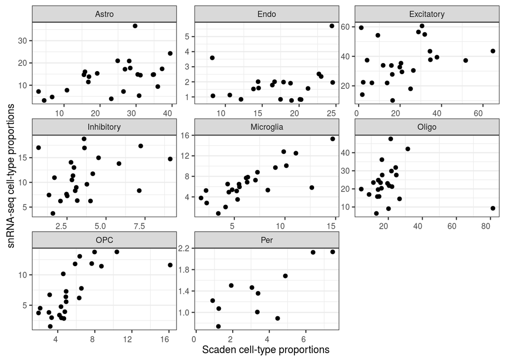

Figure 4.1: Scatterplot of cell-type proportions derived from snRNA-seq labelling or from scaden predictions across cell types.

```r
data_to_plot <-
  results$ranks %>%
           dplyr::filter(source == "Scaden deconvolution" & cells == 100 & samples == 1000 |
                           source == "snRNA-seq") %>%
  dplyr::select(sample_id, Celltype, cell_type_proportion, source) %>%
  tidyr::spread(key = source, value = cell_type_proportion)  %>%
  dplyr::filter(Celltype != "Unclassified")

data_to_plot %>%
  ggplot(aes(x = `Scaden deconvolution`, y = `snRNA-seq`)) +
  geom_point() +
  facet_wrap(~ Celltype, scales = "free") +
  labs(x = "Scaden cell-type proportions", y = "snRNA-seq cell-type proportions") +
  theme_rhr +
  theme(axis.text.x = element_text(angle = 0))
```

```r
# Overall correlation
print("Overall correlation")
```

```
## [1] "Overall correlation"
```

```r
cor.test(data_to_plot$`Scaden deconvolution`,
         data_to_plot$`snRNA-seq`,
         method = "spearman")
```

```
##
##  Spearman's rank correlation rho
##
## data:  data_to_plot$`Scaden deconvolution` and data_to_plot$`snRNA-seq`
## S = 523352, p-value = 1.225e-08
## alternative hypothesis: true rho is not equal to 0
## sample estimates:
##      rho
## 0.414071
```

```r
# Correlation of rankings for each cell type between scaden predictions and snRNA-seq proportions
print("Correlation by cell type")
```

```
## [1] "Correlation by cell type"
```

```r
data_to_plot %>%
  dplyr::filter(Celltype != "Unclassified") %>%
  tidyr::nest(-Celltype) %>%
  dplyr::mutate(test = purrr::map(data, ~ cor.test(.x$`Scaden deconvolution`, .x$`snRNA-seq`, method = "spearman")),
                tidied = map(test, broom::tidy)) %>%
  tidyr::unnest(tidied, .drop = TRUE) %>%
  dplyr::select(-data, -test) %>%
  DT::datatable(rownames = FALSE,
                options = list(scrollX = TRUE),
                class = 'white-space: nowrap')
```

| Celltype | estimate | statistic | p.value | method | alternative |
| --- | --- | --- | --- | --- | --- |
| Astro | 0.463478260869565 | 1234 | 0.0236866373084809 | Spearman's rank correlation rho | two.sided |
| Endo | 0.172932330827068 | 1100 | 0.464262598704601 | Spearman's rank correlation rho | two.sided |
| Excitatory | 0.381739130434783 | 1422 | 0.0665479185247197 | Spearman's rank correlation rho | two.sided |
| Inhibitory | 0.380869565217391 | 1424 | 0.0672088977501911 | Spearman's rank correlation rho | two.sided |
| Microglia | 0.805217391304348 | 448 | 3.74086098301852e-06 | Spearman's rank correlation rho | two.sided |
| Oligo | 0.283478260869565 | 1648 | 0.178987871818552 | Spearman's rank correlation rho | two.sided |
| OPC | 0.769565217391304 | 530 | 1.76561660853493e-05 | Spearman's rank correlation rho | two.sided |
| Per | 0.618181818181818 | 84 | 0.0478169053553036 | Spearman's rank correlation rho | two.sided |

- Overall correlation of cell type proportions derived from scaden or snRNA-seq showed a significant positive correlation, with a decent rho, which is promising.
- It's clear the correlation is stronger for some cell types compared to others e.g. strong correlation for microglia and OPCs, as compared to endothelial cells.

## 4.2 Cell-type proportions across disease groups

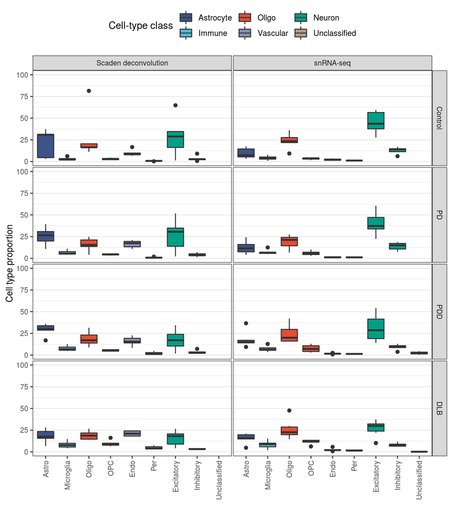

Figure 4.2: Cell-type proportions derived from scaden deconvolution predictions or single-nuclear cell-type assignments grouped by disease status. Scaden neural networks were trained using simulated bulk RNA-sequencing profiles generated from each individual's single-nuclear RNA-sequencing data; 1000 simulated bulk samples were prepared per subject, using 100 nuclei per sample. Once trained, Scaden was used to predict cell-type proportions for bulk RNA-sequencing data derived from the same individuals. Single-nuclear cell-type proportions were calculated per individual, by dividing the number of cells assigned to a cell type by the total number of cells. Cell-type proportions are summarised by cell type in each disease group. Cell types are coloured by their overarching cell-type class.

```r
results$ranks %>%
  dplyr::filter(source == "Scaden deconvolution" & cells == 100 & samples == 1000 | source == "snRNA-seq") %>%
  ggplot(aes(x = fct_relevel(Celltype,
                             results$ranks %>%
                               dplyr::filter(source == "Scaden deconvolution" & cells == 100 & samples == 1000) %>%
                               arrange(Celltype_class, Celltype) %>%
                               .[["Celltype"]] %>%
                               unique() %>%
                               as.character()),
             y = cell_type_proportion,
             fill = Celltype_class)) +
  geom_boxplot() +
  facet_grid(Disease_Group ~ source) +
  ylim(0,100) +
  scale_fill_manual(values = pal_npg("nrc", alpha = 1)(10)[c(4,2,1,6,3,10)]) +
  labs(x = "", y = "Cell type proportion", fill = "Cell-type class") +
  theme_rhr
```

```r
plot <- results$ranks %>%
  dplyr::filter(source == "Scaden deconvolution" & cells == 1000 & samples == 1000 & Disease_Group == "Control" & Celltype != "Unclassified") %>%
  ggplot(aes(x = fct_relevel(Celltype,
                             results$ranks %>%
                               dplyr::filter(source == "Scaden deconvolution" & cells == 100 & samples == 1000) %>%
                               arrange(Celltype_class, Celltype) %>%
                               .[["Celltype"]] %>%
                               unique() %>%
                               as.character()),
             y = cell_type_proportion,
             fill = Celltype_class)) +
  geom_boxplot() +
  # ylim(0,100) +
  scale_fill_manual(values = pal_npg("nrc", alpha = 1)(10)[c(4,2,1,6,3,10)]) +
  labs(x = "", y = "Cell type proportion", fill = "Cell-type class") +
  theme_rhr

# ggsave(plot,
#        filename = "/home/rreynolds/projects/Aim2_PDsequencing_wd/figures/Departmental/control_deconvolution_prop.tiff",
#        height = 120,
#        width = 100,
#        dpi = 200,
#        units = "mm")

# # Median by cell type
# medians <- results$ranks %>%
#   dplyr::filter(source == "Scaden deconvolution" & cells == 100 & samples == 1000 | source == "snRNA-seq") %>%
#   dplyr::group_by(source, Disease_Group, Celltype) %>%
#   dplyr::summarise(median_scaden = median(cell_type_proportion, na.rm = TRUE)) %>%
#   dplyr::arrange(Celltype)
```

- Looking at control populations again, oligodendrocytes come out as the top glial cell type by proportions using snRNA-seq-derived proportions, but not with scaden predictions, where the top glial cell type is astrocytes.
- Notably, looking at both snRNA-seq-derived proportions and scaden predictions the microglial population is small in controls (< expected 10%).
- Endothelial cells and pericytes have very low proportions according to snRNA-seq proportions, while scaden predicts higher proportions.
- What is reassuring with scaden predictions is that we do see an increase in endothelial and microglia numbers in disease groups, which correlates with some of the enriched pathways that are appearing in diffential gene/splicing analyses e.g. immune response, immune cell migration, transendothelial migration etc.

## 4.3 Glia-to-neuron ratios

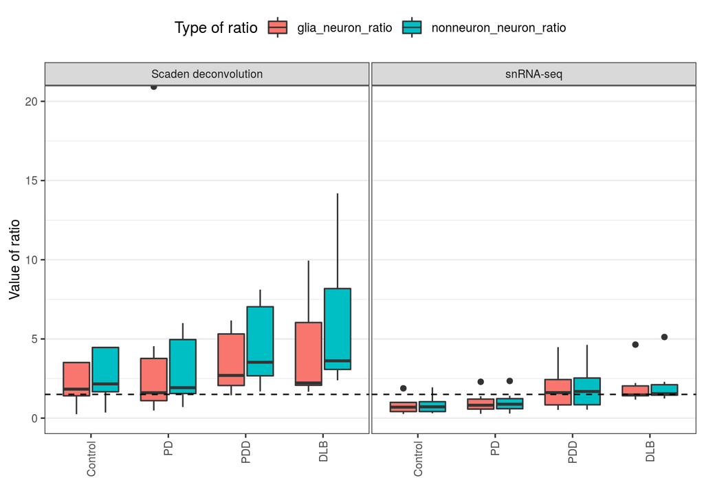

Figure 4.3: Ratio of glia-to-neurons and non-neurons-to-neurons across disease groups, as calculated using cell-type proportions derived from scaden deconvolution predictions or single-nuclear cell-type assignments. Scaden neural networks were trained using simulated bulk RNA-sequencing profiles generated from each individual's single-nuclear RNA-sequencing data; 1000 simulated bulk samples were prepared per subject, using 100 nuclei per sample.

```r
results$ratios %>%
  dplyr::filter(source == "Scaden deconvolution" & cells == 100 & samples == 1000 | source == "snRNA-seq") %>%
  ggplot(aes(x = Disease_Group, y = value)) +
  geom_boxplot(aes(fill = ratio)) +
  geom_hline(yintercept = 1.5, linetype = 2, colour = "black") +
  facet_wrap(~ source) +
  labs(x = "", y = "Value of ratio", fill = "Type of ratio") +
  coord_cartesian(ylim = c(0,20)) +
  theme_rhr
```

```r
plot <-
  results$ratios %>%
  dplyr::filter(source == "Scaden deconvolution" & cells == 1000 & samples == 1000 & ratio == "glia_neuron_ratio" & Disease_Group == "Control") %>%
  ggplot(aes(x = Disease_Group, y = value)) +
  geom_boxplot() +
  geom_hline(yintercept = 1.5, linetype = 2, colour = "black") +
  labs(x = "", y = "Glia:neuron ratio") +
  scale_y_continuous(limits = c(0,10)) +
  # coord_cartesian(ylim = c(0,20)) +
  theme_rhr

# ggsave(plot,
#        filename = "/home/rreynolds/projects/Aim2_PDsequencing_wd/figures/Departmental/glia_neuron_ratio.tiff",
#        device = "tiff",
#        height = 120,
#        width = 30,
#        dpi = 200,
#        units = "mm")

# # Median values
# ratios %>%
#   dplyr::group_by(source, Disease_Group, ratio) %>%
#   dplyr::summarise(median = median(value))
```

- Median glia:neuron ratio for controls calculated using scaden predictions is 1.83, compared to the median 0.69 for controls using snRNA-seq-determined proportions. Scaden predictions are closer to the expected ~1.5.

# 5 Optimising Scaden

## 5.1 Tweakable arguments

1. Per subject, the number of cells used to generate simulated bulk samples.
   1. Defining a bulk sample by 100 cells appears quite low, so worth trying to increase to the max. possible value.
   2. Lower bound of max. value will be determined by our smallest number of nuclei in an individual sample. According to figure below, lower bound is around 3000 cells. Thus, try running with 500, 1000 and 2000 cells, with 1000 simulated samples (to keep compute costs smaller).

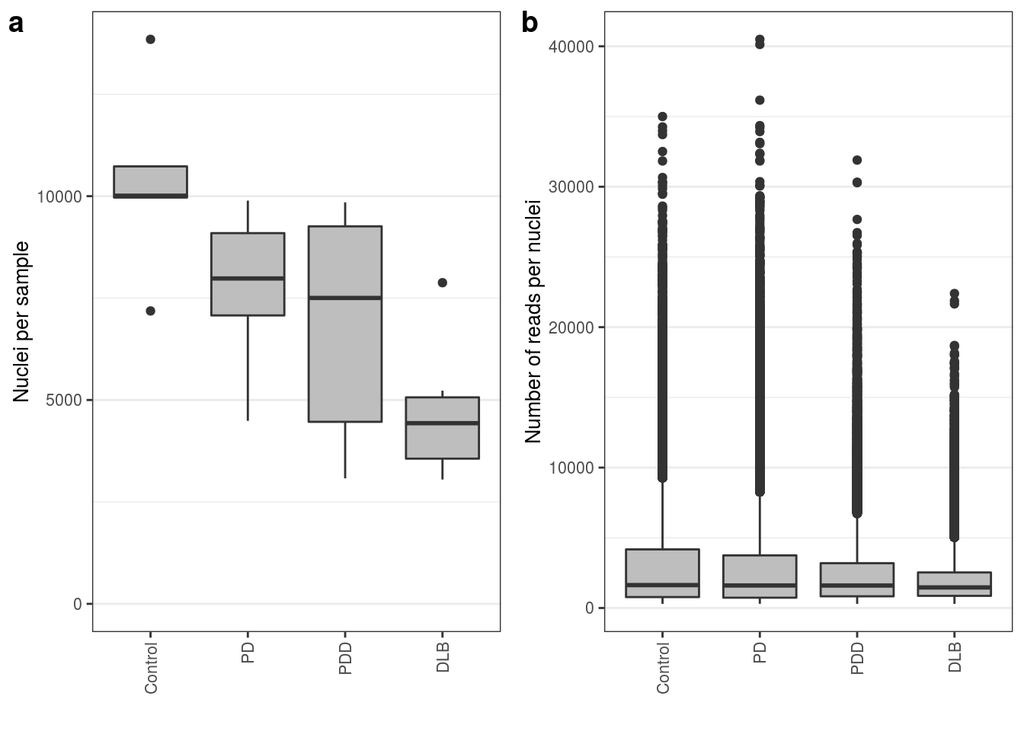

      Figure 5.1: Number of (a) nuclei per sample or (b) reads per nucleus grouped by disease.

2. Per subject, the number of simulated bulk samples generated.
   1. Run with 1000, 2000 and 4000 samples.
3. Scale factor on bulk data -- this will influence the number of genes included when training the model.
   1. Currently this is scaled to counts per million (CPM), which is a recognised scale in RNA-seq. Currently this results in ~ 13,000 genes in common between bulk and snRNA-seq data. As CPM is a recognised scale, choose to stick with this for now (easier to defend).
4. Number of steps each model is trained for.
   1. Given article recommendation of 5000 (to avoid overfitting), will stick with this for now so as not to change too many variables at the same time.

## 5.2 Running Scaden optimisation

- Created a shell script to run end-to-end scaden process i.e. from generating bulk --> prediction. Link: scaden_script.sh
- Ran 500, 1000 and 2000 cells with 1000 samples. Also ran 1000 cells with 2000 and 4000 samples.

```bash
# Copy scaden_script.sh to docker container
docker cp /home/rreynolds/projects/Aim2_PDsequencing_wd/LBD-seq-bulk-analyses/misc_scripts/scaden_script.sh scaden_rreynolds:/home/scripts/scaden_script.sh

# Run script for each sample scenario after navigating to docker and re-initiating
bash /home/scripts/scaden_script.sh --sample_dir=/home/data/PD_seq/scaden/samples/ --n_cells=500 --n_simulated_samples=1000 --n_training_steps=5000 --pred_path=/home/data/PD_seq/scaden/samples/bulkRNAseq_norm_counts.txt

bash /home/scripts/scaden_script.sh --sample_dir=/home/data/PD_seq/scaden/samples/ --n_cells=1000 --n_simulated_samples=1000 --n_training_steps=5000 --pred_path=/home/data/PD_seq/scaden/samples/bulkRNAseq_norm_counts.txt

bash /home/scripts/scaden_script.sh --sample_dir=/home/data/PD_seq/scaden/samples/ --n_cells=2000 --n_simulated_samples=1000 --n_training_steps=5000 --pred_path=/home/data/PD_seq/scaden/samples/bulkRNAseq_norm_counts.txt

bash /home/scripts/scaden_script.sh --sample_dir=/home/data/PD_seq/scaden/samples/ --n_cells=1000 --n_simulated_samples=2000 --n_training_steps=5000 --pred_path=/home/data/PD_seq/scaden/samples/bulkRNAseq_norm_counts.txt

bash /home/scripts/scaden_script.sh --sample_dir=/home/data/PD_seq/scaden/samples/ --n_cells=1000 --n_simulated_samples=4000 --n_training_steps=5000 --pred_path=/home/data/PD_seq/scaden/samples/bulkRNAseq_norm_counts.txt
```

## 5.3 Results

### 5.3.1 Cell-type proportions across disease groups

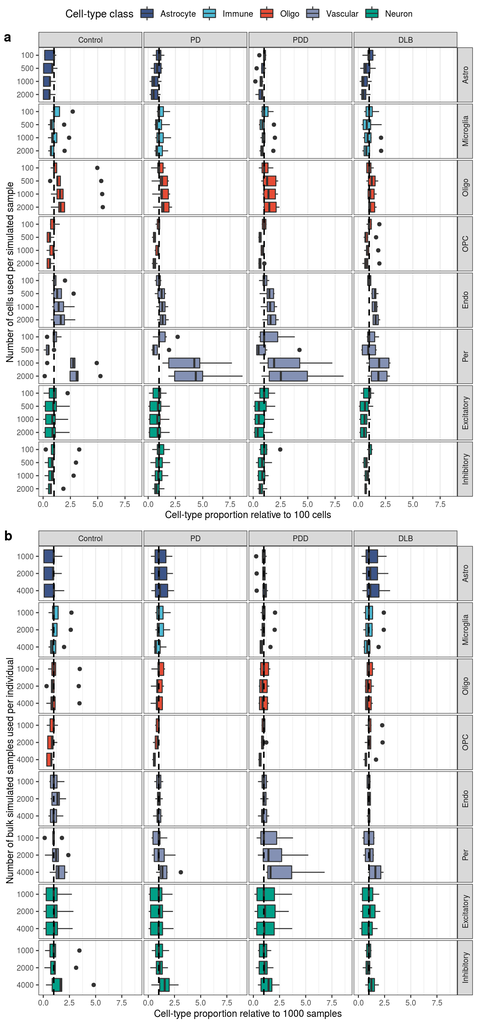

Figure 5.2: Cell-type proportions as predicted by Scaden using (a) an increasing number of cells per simulated sample or (b) an increasing number of bulk simulated samples per subject. Scaden was run with (a) 100, 500, 1000 or 2000 cells to generate 1000 bulk simulated samples per subject or (b) 1000 cells to generate 1000, 2000 or 4000 bulk simulated samples per subject. Cell-type proportions are grouped by cell type and disease status, displayed relative to the median of (a) 100 cells or (b) 1000 samples (median indicated with black dashed line) and coloured by their overarching cell-type class.

```r
# # Plots showing raw cell-type proportions
# a <- results$ranks %>%
#   dplyr::mutate(cells = fct_relevel(cells,
#                               c("100", "500", "1000", "2000"))) %>%
#   dplyr::filter(source == "Scaden deconvolution" & Celltype!= "Unclassified" & samples == "1000") %>%
#   ggplot(aes(x = cells,
#              y = cell_type_proportion,
#              fill = Celltype_class)) +
#   geom_boxplot() +
#   facet_grid(cols = vars(Disease_Group),
#              rows = vars(fct_relevel(Celltype,
#                                      results$ranks %>%
#                                        dplyr::mutate(cells_samples = str_c("cells.", cells, "_samples.", samples)) %>%
#                                        dplyr::filter(source == "Scaden deconvolution" & Celltype!= "Unclassified") %>%
#                                        arrange(source, cells_samples, Celltype_class, Celltype) %>%
#                                        .[["Celltype"]] %>%
#                                        unique() %>%
#                                        as.character())),
#              scales = "free_y") +
#   # ylim(0,100) +
#   scale_fill_manual(values = pal_npg("nrc", alpha = 1)(10)[c(4,2,1,6,3,10)]) +
#   labs(x = "Number of cells used per simulated sample", y = "Cell type proportion", fill = "Cell-type class") +
#   theme_rhr
#
# b <- results$ranks %>%
#   dplyr::filter(source == "Scaden deconvolution" & Celltype!= "Unclassified" & cells == "1000") %>%
#   ggplot(aes(x = samples,
#              y = cell_type_proportion,
#              fill = Celltype_class)) +
#   geom_boxplot() +
#   facet_grid(cols = vars(Disease_Group),
#              rows = vars(fct_relevel(Celltype,
#                                      results$ranks %>%
#                                        dplyr::mutate(cells_samples = str_c("cells.", cells, "_samples.", samples)) %>%
#                                        dplyr::filter(source == "Scaden deconvolution" & Celltype!= "Unclassified") %>%
#                                        arrange(source, cells_samples, Celltype_class, Celltype) %>%
#                                        .[["Celltype"]] %>%
#                                        unique() %>%
#                                        as.character())),
#              scales = "free_y") +
#   # ylim(0,100) +
#   scale_fill_manual(values = pal_npg("nrc", alpha = 1)(10)[c(4,2,1,6,3,10)]) +
#   labs(x = "Number of bulk simulated samples used per individual", y = "Cell type proportion", fill = "Cell-type class") +
#   theme_rhr


a <- results$ranks %>%
  dplyr::filter(source == "Scaden deconvolution" & Celltype!= "Unclassified" & samples == "1000") %>%
  dplyr::select(-rank_within_sample) %>%
  # Spread columns and group by Disease & Celltype to calculate median for 100 cells
  tidyr::spread(key = cells, value = cell_type_proportion) %>%
  dplyr::group_by(Disease_Group, Celltype) %>%
  dplyr::mutate(median_100 = median(`100`)) %>%
  dplyr::ungroup() %>%
  # Calculate fold change from reference, 100 cells, by dividing each column by median_100
  dplyr::mutate_at(.vars = vars(`100`, `500`, `1000`, `2000`), .funs = function(x){x/.[["median_100"]]}) %>%
  dplyr::select(-median_100) %>%
  tidyr::gather(key = "cells", value = "cell_type_proportion_relative_to_100_cells", -sample_id, -Celltype, -source, -samples, -Celltype_class, -Disease_Group) %>%
  ggplot(aes(x = fct_relevel(cells,
                             rev(c("100", "500", "1000", "2000"))),
             y = cell_type_proportion_relative_to_100_cells,
             fill = Celltype_class)) +
  geom_boxplot() +
  geom_hline(aes(yintercept = 1), colour = "black", linetype = "dashed", size = 0.75) +
  facet_grid(cols = vars(Disease_Group),
             rows = vars(fct_relevel(Celltype,
                                     results$ranks %>%
                                       dplyr::mutate(cells_samples = str_c("cells.", cells, "_samples.", samples)) %>%
                                       dplyr::filter(source == "Scaden deconvolution" & Celltype!= "Unclassified") %>%
                                       arrange(source, cells_samples, Celltype_class, Celltype) %>%
                                       .[["Celltype"]] %>%
                                       unique() %>%
                                       as.character()))) +
  scale_fill_manual(values = pal_npg("nrc", alpha = 1)(10)[c(4,2,1,6,3,10)]) +
  labs(x = "Number of cells used per simulated sample", y = "Cell-type proportion relative to 100 cells", fill = "Cell-type class") +
  theme_rhr_coord_flip +
  coord_flip()

b <- results$ranks %>%
  dplyr::filter(source == "Scaden deconvolution" & Celltype!= "Unclassified" & cells == "1000") %>%
  dplyr::select(-rank_within_sample) %>%
  # Spread columns and group by Disease & Celltype to calculate median for 1000 samples
  tidyr::spread(key = samples, value = cell_type_proportion) %>%
  dplyr::group_by(Disease_Group, Celltype) %>%
  dplyr::mutate(median_1000 = median(`1000`)) %>%
  dplyr::ungroup() %>%
  # Calculate fold change from reference, 1000 samples, by dividing each column by median_1000
  dplyr::mutate_at(.vars = vars(`1000`, `2000`, `4000`), .funs = function(x){x/.[["median_1000"]]}) %>%
  dplyr::select(-median_1000) %>%
  tidyr::gather(key = "samples", value = "cell_type_proportion_relative_to_1000_samples", -sample_id, -Celltype, -source, -cells, -Celltype_class, -Disease_Group) %>%
  ggplot(aes(x = fct_relevel(samples,
                             rev(c("1000", "2000", "4000"))),
             y = cell_type_proportion_relative_to_1000_samples,
             fill = Celltype_class)) +
  geom_boxplot() +
  geom_hline(aes(yintercept = 1), colour = "black", linetype = "dashed", size = 0.75) +
  facet_grid(cols = vars(Disease_Group),
             rows = vars(fct_relevel(Celltype,
                                     results$ranks %>%
                                       dplyr::mutate(cells_samples = str_c("cells.", cells, "_samples.", samples)) %>%
                                       dplyr::filter(source == "Scaden deconvolution" & Celltype!= "Unclassified") %>%
                                       arrange(source, cells_samples, Celltype_class, Celltype) %>%
                                       .[["Celltype"]] %>%
                                       unique() %>%
                                       as.character()))) +
  ylim(0,9) +
  scale_fill_manual(values = pal_npg("nrc", alpha = 1)(10)[c(4,2,1,6,3,10)]) +
  scale_colour_manual(values = pal_npg("nrc", alpha = 1)(10)[c(4,2,1,6,3,10)]) +
  labs(x = "Number of bulk simulated samples used per individual", y = "Cell-type proportion relative to 1000 samples", fill = "Cell-type class") +
  theme_rhr_coord_flip +
  coord_flip()

ggarrange(a, b,
          labels = c("a", "b"),
          nrow = 2,
          common.legend = TRUE)
```

- Regardless of whether we increase the number of cells per simulated sample or the number of simulated samples per subject, the effect of this across disease groups is the same e.g. increasing the number of cells per simulated sample decreases the proportion of astrocytes predicted in controls, DLB, PD and PDD. Good sanity check, as we would not expect to see one disease group disproportionately affected by changing scaden parameters.
- Do, however, see that the effect of increasing the number of cells per simulated sample or the number of simulated samples per subject varies according to the cell type in question. E.g. Increasing the number of cells per simulated sample decreases the proportion of astrocytes predicted across all disease groups, while it appears to increase the proportion of oligodendrocytes predicted.
- Looking at controls alone, increasing number of cells per simulated sample appears to have more of an impact on predicted cell-type proportions (in particular, non-neuronal cell types such as astrocytes, oligodendrocytes, endothelial cells and pericytes) than increasing the number of simulated samples per subject.

### 5.3.2 Glia-to-neuron ratios

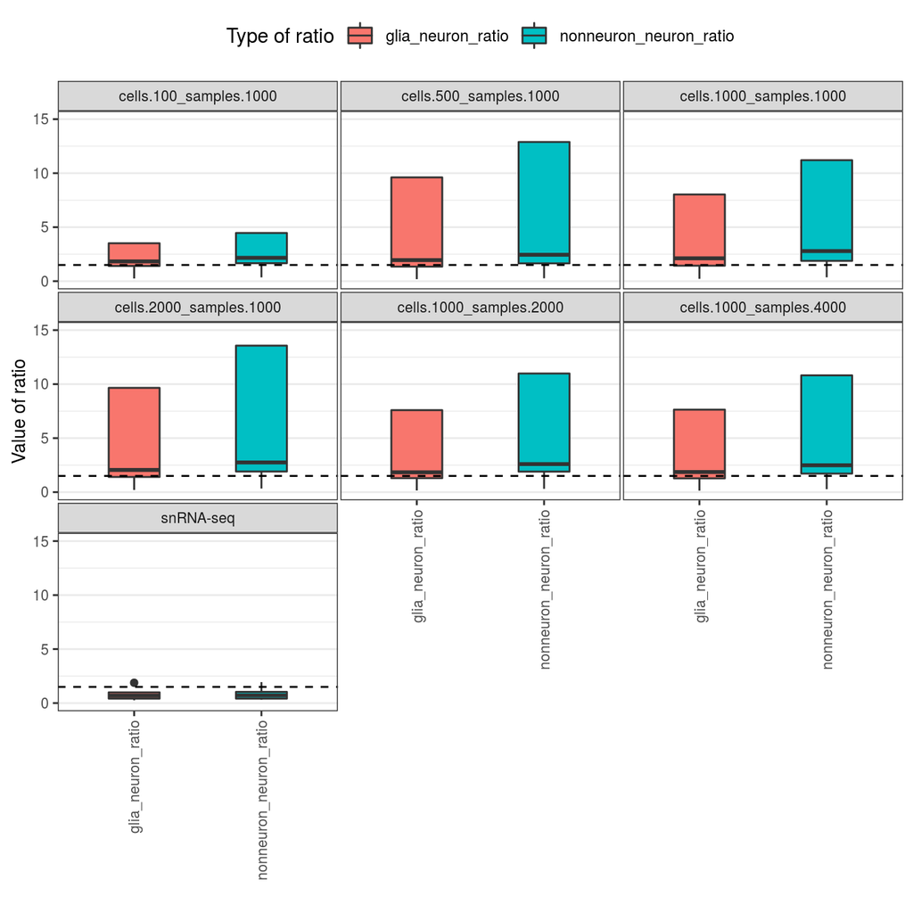

Figure 5.3: Ratio of glia-to-neurons and non-neurons-to-neurons across controls when using variations of scaden parameters i.e. cell numbers used or the number of bulk simulated samples generated.

```r
results$ratios %>%
  dplyr::mutate(cells_samples = str_c("cells.", cells, "_samples.", samples) %>%
                  tidyr::replace_na(., "snRNA-seq") %>%
                  fct_relevel(.,
                              c("cells.100_samples.1000", "cells.500_samples.1000", "cells.1000_samples.1000",
                                "cells.2000_samples.1000", "cells.1000_samples.2000", "cells.1000_samples.4000", "snRNA-seq"))) %>%
  dplyr::filter(Disease_Group == "Control") %>%
  ggplot(aes(x = ratio, y = value)) +
  geom_boxplot(aes(fill = ratio), width = 0.4) +
  geom_hline(yintercept = 1.5, linetype = 2, colour = "black") +
  facet_wrap(vars(cells_samples)) +
  labs(x = "", y = "Value of ratio", fill = "Type of ratio") +
  coord_cartesian(ylim = c(0,15)) +
  theme_rhr
```

```r
# # Median values
# ratios %>%
#   dplyr::group_by(source, Disease_Group, ratio) %>%
#   dplyr::summarise(median = median(value))
```

- Looking at glia-to-neuron and non-neuron-to-neuron ratios, increasing the number of cells per simulated sample or the number of simulated samples per subject both increase the spread of the data, without any noticeable impact upon the median.

### 5.3.3 Ranking performance based on deviation from "ground truth"

```r
source(here::here("R", "scoring_deconvolution_performance.R"))

scoring_deconvolution_performance(results_list = results %>%
                                    lapply(., function(x){x %>% dplyr::filter(Disease_Group == "Control" & source == "Scaden deconvolution")}),
                                  true_GNR = 1.5,
                                  deconvolution_variables = vars(cells, samples),
                                  glia = c("Astro", "Microglia", "Oligo"),
                                  oligo = c("Oligo"),
                                  astrocyte = c("Astro"),
                                  microglia = c("Microglia"),
                                  use_ranges = TRUE) %>%
  dplyr::arrange(overall_rank, GNR_rank) %>%
  dplyr::select(cells, samples, overall_rank, overall_score, everything()) %>%
  DT::datatable(rownames = FALSE,
                options = list(scrollX = TRUE),
                class = 'white-space: nowrap')
```

| cells | samples | overall_rank | overall_score | GNR_rank | astro_glial_prop_within_range_rank | micro_glial_prop_within_range_rank | oligo_glial_prop_within_range_rank | astro_glial_prop_deviation_from_mean_rank | micro_glial_prop_deviation_from_mean_rank | oligo_glial_prop_deviation_from_mean_rank | glia_ranking_score |
| --- | --- | --- | --- | --- | --- | --- | --- | --- | --- | --- | --- |
| 1000 | 1000 | 2 | 4 | 2 | 2.5 | 2 | 2 | 2 | 3 | 2 | 2 |
| 2000 | 1000 | 2 | 4 | 3 | 2.5 | 5 | 2 | 1 | 5 | 1 | 4.5 |
| 1000 | 2000 | 2 | 4 | 5 | 2.5 | 2 | 2 | 3 | 2 | 3 | 2 |
| 100 | 1000 | 4 | 3 | 1 | 6 | 2 | 5 | 4 | 1 | 6 | 4.5 |
| 1000 | 4000 | 5 | 2 | 6 | 2.5 | 5 | 5 | 6 | 4 | 5 | 2 |
| 500 | 1000 | 6 | 0 | 4 | 5 | 5 | 5 | 5 | 6 | 4 | 6 |

- Definition of scores:
  - `overall_rank`: final ranking of deconvolution instances based on `overall_score` i.e. highest overall score receives rank of 1
  - `overall_score`: overall score across the five scoring parameters (GNR_score, *_glial_proportion and glia ranking_score). For each scoring parameter, award score of 1 to the deconvolution instance(s) with the highest rank (where 1 = best).
  - `GNR_rank`: ranking of instances from best (equivalent to rank of 1) to worst by the deviation of its median glia-to-neuron ratio from the true ratio.
  - `*_glial_proportion`: ranking of each instance from best (equivalent to rank of 1) to worst based on the proportion of samples within a deconvolution instance that have a proportion of the glial cell-type in question that falls within expected ranges.
  - `*_glial_proportion_deviation_from_mean`: ranking of each instance from best (equivalent to rank 1) to worst by the deviation of its median astro/oligo/microglial glial proportion from the expected mean across 3 studies.
  - `glia_ranking_score`: ranking of deconvolution instance form best (equivalent to rank of 1) to worst by the proportion of samples wherein oligodendrocytes make up the biggest glial cell-type population, followed by astrocytes and then microglia.
- If values tie upon ranking, the average of their combined ranks is computed.
- **Conclusion:** based on overall ranks, best performing parameters included using 1000 cells with either 1000 or 2000 bulk simulated samples OR 2000 cells with 1000 samples. Looking at GNR, 1000 cells and 1000 samples ranked 2nd, as opposed to 3rd and 5th. Based on this, would choose this parameter.

# 6 Summary

- Final choice of parameters = 1000 cells and 1000 samples, as based on ranking according to deviation from "ground truth".
- Using these parameters, we can plot cell-type proportions across disease groups and test for any differences between groups.

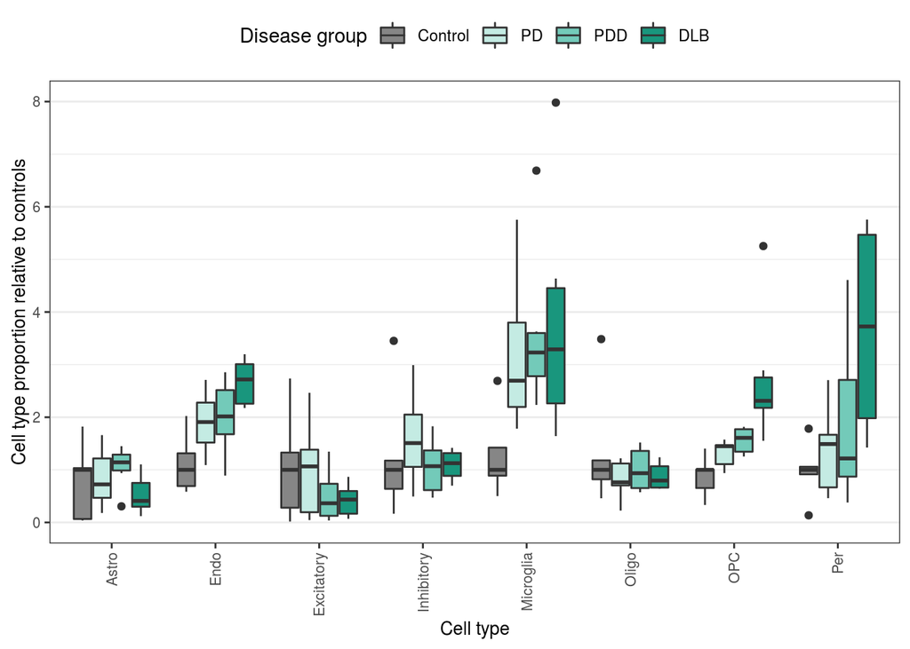

Figure 6.1: Cell-type proportions derived from scaden deconvolution. Scaden neural networks were trained using simulated bulk RNA-sequencing profiles generated from each individual's single-nuclear RNA-sequencing data; 1000 simulated bulk samples were prepared per subject, using 1000 nuclei per sample. Once trained, Scaden was used to predict cell-type proportions for bulk RNA-sequencing data derived from the same individuals. Cell-type proportions are grouped by cell type and disease status and displayed relative to the median of controls (within a cell type).

```r
plot <- results$ranks %>%
  dplyr::filter(source == "Scaden deconvolution" & Celltype!= "Unclassified" & cells == "1000" & samples == "1000") %>%
  dplyr::select(-rank_within_sample, -cells, -samples, -source) %>%
  tidyr::spread(key = Disease_Group, value = cell_type_proportion) %>%
  dplyr::group_by(Celltype) %>%
  dplyr::mutate(median_control = median(Control, na.rm = T)) %>%
  dplyr::ungroup() %>%
  # Calculate fold change from reference, controls, by dividing each column by median_control
  dplyr::mutate_at(.vars = vars("Control", "PD", "PDD", "DLB"), .funs = function(x){x/.[["median_control"]]}) %>%
  dplyr::select(-median_control) %>%
  tidyr::gather(key = "Disease_Group", value = "cell_type_proportion_relative_to_control", -sample_id, -Celltype, -Celltype_class) %>%
  # dplyr::filter(Celltype == "Excitatory") %>%
  ggplot(aes(x = Celltype,
             y = cell_type_proportion_relative_to_control,
             fill = fct_relevel(Disease_Group,
                                c("Control", "PD", "PDD", "DLB")))) +
  geom_boxplot() +
  # scale_fill_manual(values = pal_jco("default", alpha = 0.9)(10)[c(3,9,1,2)]) +
  scale_fill_manual(values = c("#868686", "#c4ebe3", "#73cab9", "#19967d")) +
  coord_cartesian(ylim = c(0,8)) +
  labs(x = "Cell type", y = "Cell type proportion relative to controls", fill = "Disease group") +
  theme_rhr

plot
```

```r
# ggsave(plot,
#        filename = "/home/rreynolds/projects/Aim2_PDsequencing_wd/figures/IPDGC_presentation/scaden_deconvolution_exct.tiff",
#        device = "tiff",
#        dpi = 200,
#        width = 50,
#        height = 120,
#        units = "mm")

# # Median by cell type
# medians <- results$ranks %>%
#   dplyr::filter(source == "Scaden deconvolution" & Celltype!= "Unclassified" & cells == "1000" & samples == "1000") %>%
#   dplyr::group_by(source, Disease_Group, Celltype) %>%
#   dplyr::summarise(median_scaden = median(cell_type_proportion, na.rm = TRUE)) %>%
#   dplyr::arrange(Celltype)
```

## 6.1 Wilcoxon rank-sum test results

```r
results$ranks %>%
  dplyr::filter(source == "Scaden deconvolution" & Celltype!= "Unclassified" & cells == "1000" & samples == "1000") %>%
  dplyr::group_by(Celltype) %>%
  dplyr::do(pairwise.wilcox.test(x= .$cell_type_proportion, g = .$Disease_Group, p.adjust.method = "none", paired = FALSE) %>%
              broom::tidy()) %>%
  dplyr::mutate(fdr = p.adjust(p.value, method = "BH")) %>%
  dplyr::arrange(fdr) %>%
  DT::datatable(rownames = FALSE,
                options = list(scrollX = TRUE),
                class = 'white-space: nowrap')
```

| Celltype | group1 | group2 | p.value | fdr |
| --- | --- | --- | --- | --- |
| OPC | DLB | Control | 0.00432900432900433 | 0.012987012987013 |
| OPC | DLB | PD | 0.00233100233100233 | 0.012987012987013 |
| Endo | DLB | Control | 0.00432900432900433 | 0.025974025974026 |
| OPC | PDD | Control | 0.0173160173160173 | 0.025974025974026 |
| OPC | DLB | PDD | 0.0151515151515152 | 0.025974025974026 |
| Microglia | PDD | Control | 0.00865800865800866 | 0.051948051948052 |
| Per | DLB | Control | 0.00865800865800866 | 0.051948051948052 |
| Microglia | PD | Control | 0.0176767676767677 | 0.053030303030303 |
| Microglia | DLB | Control | 0.0303030303030303 | 0.0606060606060606 |
| Endo | PD | Control | 0.047979797979798 | 0.0974025974025974 |

[output cut: 38 more lines]

### 6.1.1 How robust is this?

- Can investigate this by performing pairwise comparisons of disease groups across each combination of cells x samples, and then ranking p-values.
- Figure below shows that rankings remain stable despite changing cells x samples combinations.

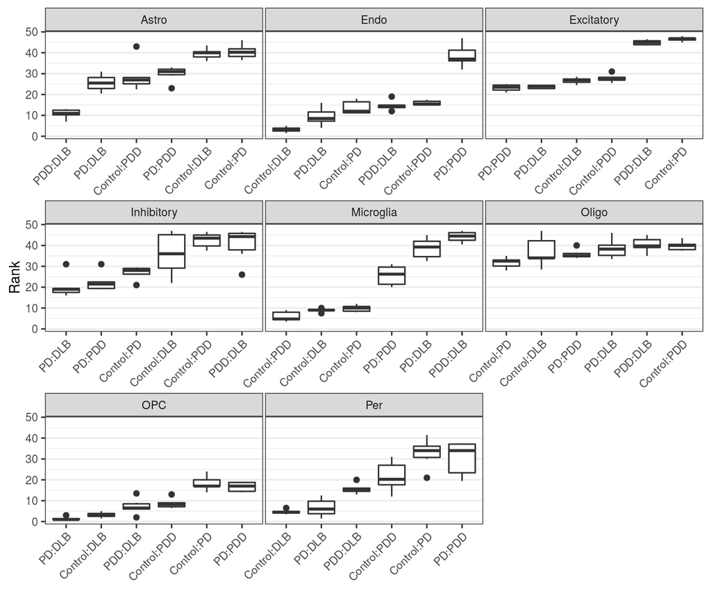

Figure 6.2: Ranking of p-values derived from Wilcoxon rank sum tests run for each combination of cells x samples (total of 6 different combinations - 100,500,1000 and 2000 cells run with 1000 samples and 1000 cells run with 2000 and 4000 samples). Lower rank = lower p-value.

```r
results$ranks %>%
  dplyr::filter(source == "Scaden deconvolution" & Celltype!= "Unclassified") %>%
  dplyr::mutate(combined = str_c(cells, ":", samples)) %>%
  dplyr::group_by(combined, Celltype) %>%
  dplyr::do(pairwise.wilcox.test(x= .$cell_type_proportion, g = .$Disease_Group, p.adjust.method = "none", paired = FALSE) %>%
              broom::tidy()) %>%
  dplyr::group_by(combined) %>%
  dplyr::mutate(fdr = p.adjust(p.value, method = "BH"),
                rank = rank(p.value, ties.method = "average"),
                comparison = str_c(group2, ":", group1)) %>%
  ggplot(aes(x = reorder_within(x = comparison, by = rank, within = Celltype, fun = median, desc = F), y = rank)) +
  geom_boxplot() +
  facet_wrap(vars(Celltype), scales = "free_x") +
  scale_x_reordered() +
  labs(x = "", y = "Rank") +
  theme_rhr +
  theme(axis.text.x = element_text(angle = 45, hjust = 1, vjust = 1))
```

## 6.2 Linking with other analyses

- Pathway analyses using differentially expressed genes prior to correction for cell types identified a number of immune terms for several comparisons (Ctrl vs DLB, Ctrl vs PDD, DLB vs PD) and immune-related migration terms (Ctrl vs DLB, Ctrl vs PDD) --> fits with microglia profile, and likewise endothelial and pericyte profile.
- Pathway analyses using differentially expressed genes prior to correction for cell types identified a number of contractile terms for Ctrl vs DLB ("smooth muscle contraction") and particularly for DLB vs PDD, which was almost exclusively contractile terms --> fits with pericyte profiler? Could this be pericytes showing a [contractile profile](https://link.springer.com/article/10.1023/A:1011965307612)? Abeta oligomers previously shown to constrict capillaries via [perictyes](https://science.sciencemag.org/content/365/6450/eaav9518.full?ijkey=et4WmDfvR1Tig&keytype=ref&siteid=sci).